# 최종_활성화함수

## Part1. 기계학습

- 예측과 분류를 하는 모델제작
  - 정형데이터(숫자, 문자, 날짜) : 머신러닝(통계적, sklearn(wb계산공식이있음))
  - 비정형데이터(이미지,소리, 영상, 문장) : 딥러닝(인공신경망, tensorflow(최소한의수식만제공,wb를 계속찾는과정))
  - 지도학습: x(특징)과 y(레이블)을 제공함.
  - 비지도학습: y값 없음(x데이터간의 유사도판별같은거 해서 그룹분류)

## Part2. 딥러닝기초, 지도학습

-

#### [2-1] 모듈import

- import 폴더명 as 별명 : 폴더명의 **init**.py를 실행
- from 폴더명 import 파일명 : 폴더안의 파일명.py를 실행
- 참고) 추후에는 설치해야하는 모듈과 버전이 프로젝트에 따라서 계속 달라짐
  - 반드시 가상환경을 권장하고, 별도의 txt파일에 설치할 모듈명만 따로 기재
  - 즉 진행하고 있는 프로젝트에 사용하는 모듈을 저장하는 기능이 있어서 그 모듈을 저장해서 txt 파일로 갖고 다님

```python
import numpy as np
import pandas as pd
import matplotlib.pyplot as plt
import tensorflow as tf
from tensorflow.keras.models import Sequential
from tensorflow.keras.layers import Dense
```

### Part3. 기계학습에 사용되는 데이터셋

- 반드시 array여야함. (type 명령에서 numpy가 나와야함)
  - 이미지는 PIL로 open해서 np.array로 배열화를 시키거나  
    openCV로 처음부터 array로 읽기때문에 이 과정에 고민이 없음
  - 정형자료중에 pandas로 읽은 자료는 array로 변경해줘야함.
- 텐서플로우에 넣는 자료는 텐서형이여햐함. (스칼라->벡터->array->텐서)
  - 모델제작시에는 array자료를 2개이상 넣기 때문에 자동으로 차원이 한개 확장이됨
  - 제작이 끝난 모델에 새로운 자료를 한개만 넣을때는 텐서형이어야함(사용자가 해줘야함)

### Part4. 활성화함수

- 구글링

#### [4-1] 회귀분석 (예측)

- y값이 무한대의 숫자중에 한개가 나옴 (wx+b, linear 구조임)
- activation='linear' 또는 생략

```python
### 판다스를 array로 변경하는 작업을 해볼께요 (외부데이터 없어서 판다스 자료를 직접 제작해봄)
key=[180.5,165,160,170,180]
age=[20,15,35,15,40]
혈압=[130,140,135,180,140]


df=pd.DataFrame({'key':key, 'age':age, '혈압':혈압})
x=df[['key','age']].values
x=x.astype('float32')    #  float데이터일때는 텐서는 float32까지만 지원을 해줌
y=df['혈압'].values
```

```python
x.shape
```

```
(5, 2)
```

```python
model=Sequential()
model.add(Dense(5, input_dim=2, activation='relu'))  #input
model.add(Dense(1))  #output

model.compile(optimizer='adam',loss='mse',
              metrics=['accuracy'])
history=model.fit(x,y, epochs=5)


print('----기존의 x값은 어떻게 예측했을까, output레이어의 w와b가 wx+b로계산, y_hat---')
print(model.predict(x))

print('---새로운값을 넣으면 얼마로 예측할까 ')
newX=[180,35]
newX=np.reshape(newX,(1,-1))

model.predict(newX)
```

```
----기존의 x값은 어떻게 예측했을까, output레이어의 w와b가 wx+b로계산, y_hat---
[[20.741903]
 [18.797329]
 [19.249424]
 [19.34406 ]
 [21.686058]]
---새로운값을 넣으면 얼마로 예측할까
```

```
array([[21.43635]], dtype=float32)
```

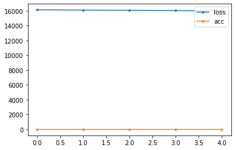

```python
loss=history.history['loss']
acc=history.history['accuracy']

plt.plot(loss, marker='.',label='loss')
plt.plot(acc,marker='.',label='acc')
plt.legend(loc='upper right')
```

### [4-2] 이진분류

- y값이 0또는1 (true, false 또는 yes,no) 중에 1개값
- 활성화함수 계산결과가 0~1 사이값이 나올수 있도록 하고 (sigmoid 일반적으로 사용됨) 그 숫자값을  
  0또는 1로 변경하는 계산식을 사용자가 작성해야함. (예를 0.5보다 크면 1, 아니면 0)  
  이때 0.5를 임계값 이라 하고 임계값도 사용자가 지정함
  - 시그모이드계산식 1 / (1+exp ** -(wx+b))

```python
### 판다스를 array로 변경하는 작업을 해볼께요 (외부데이터 없어서 판다스 자료를 직접 제작해봄)
key=[180.5,165,160,170,180]
age=[20,15,35,15,40]
혈압유무=[0,1,1,1,0]


df=pd.DataFrame({'key':key, 'age':age, '혈압유무':혈압유무})
x=df[['key','age']].values
x=x.astype('float32')    #  float데이터일때는 텐서는 float32까지만 지원을 해줌
y=df['혈압유무'].values
```

```python
model=Sequential()
model.add(Dense(5, input_dim=2, activation='relu'))  #input
model.add(Dense(1, activation='sigmoid'))  #output

model.compile(optimizer='adam',loss='binary_crossentropy',
              metrics=['accuracy'])
history=model.fit(x,y, epochs=5)
print('----기존의 x값은 어떻게 예측했을까, output레이어의 w와b가 wx+b로계산, y_hat---')
print(model.predict(x))

print('---새로운값을 넣으면 얼마로 예측할까 ')
newX=[180,35]
newX=np.reshape(newX,(1,-1))


result=model.predict(newX)

print(result)
if result>0.5:
    print('혈압조심')
else:
    print('정상')
```

```
----기존의 x값은 어떻게 예측했을까, output레이어의 w와b가 wx+b로계산, y_hat---
[[9.4135394e-12]
 [6.5433950e-11]
 [6.0146704e-10]
 [3.1084874e-11]
 [4.4282598e-11]]
---새로운값을 넣으면 얼마로 예측할까
[[3.06332e-11]]
정상
```

### [4-4] 다항분류 (softmax함수)

- y값이 2개이상의 카테고리중 어떤 카테고리인가를 분류하는것 예) 성별이 [남자,여자] , 남자일때는 [1,0] 여자일때는 [0,1]

  ```
    옷색상이 [검정,노랑,빨강,파랑] 일때는  검정->[1,0,0,0] / 노랑->[0,1,0,0], .../파랑 [0,0,0,1]
  ```

```python
### 판다스를 array로 변경하는 작업을 해볼께요 (외부데이터 없어서 판다스 자료를 직접 제작해봄)
key=[180.5,165,160,170,180]
age=[20,15,35,15,40]
혈압정도=[0,5,1,2,1]   # 5점척도 중 어디인가 카테고리 0:'보통' , 1:'경고', .... 5:'심각'


df=pd.DataFrame({'key':key, 'age':age, '혈압정도':혈압정도})
x=df[['key','age']].values
x=x.astype('float32')    #  float데이터일때는 텐서는 float32까지만 지원을 해줌
y=df['혈압정도'].values
```

##### 소프트맥스에 사용되는 y값에 대하여 이해

- 원핫인코딩 되어 있거나, 해야함
- 혈압정도 0~5사이값을 사용하면 준비하는 비트 6개 (6개비트 다 더하면 1)
  - y값이 원핫인코딩되어서 준비되어야함. 하지만 원핫인코딩 안된 y값을 넣으면 loss='sparse_categorical_crossentropy' 로 하면 원핫인코딩을 프로그램이 시킴
    - 혈압이0 [1,0,0,0,0,0]
    - 혈압이1 [0,1,0,0,0,0]
    - 혈압이2 [0,0,1,0,0,0]
    - 혈압이3 [0,0,0,1,0,0]
    - 혈압이4 [0,0,0,0,1,0]
    - 혈압이5 [0,0,0,0,0,1]
- model.predict는 6개의비트각 자리에 확률값으로 나옴(더하면 1되는)

```python
model=Sequential()
model.add(Dense(5, input_dim=2, activation='relu'))
model.add(Dense(6, activation='softmax'))    # y값이 가장 큰 숫자

model.compile(optimizer='adam',loss='sparse_categorical_crossentropy',
              metrics=['accuracy'])
history=model.fit(x,y, epochs=5)
print('----기존의 x값은 어떻게 예측했을까, output레이어의 w와b가 wx+b로계산, y_hat---')
print(model.predict(x))


print('---새로운값을 넣으면 얼마로 예측할까 ')
newX=[180,35]
newX=np.reshape(newX,(1,-1))


result=model.predict(newX)
predict_num=np.argmax(result)

class_name=['안전','보통','경증','경고','위험','중증']
class_name[predict_num]
```

```
----기존의 x값은 어떻게 예측했을까, output레이어의 w와b가 wx+b로계산, y_hat---
[[0.16722111 0.16722137 0.16722111 0.16555764 0.16555764 0.16722111]
 [0.16722111 0.16722137 0.16722111 0.16555764 0.16555764 0.16722111]
 [0.16722111 0.16722137 0.16722111 0.16555764 0.16555764 0.16722111]
 [0.16722111 0.16722137 0.16722111 0.16555764 0.16555764 0.16722111]
 [0.16722111 0.16722137 0.16722111 0.16555764 0.16555764 0.16722111]]
---새로운값을 넣으면 얼마로 예측할까
```

```
'보통'
```